# Risk Factor Analysis

## Outcome Variable

**Outcome Variable:** ever_stunted

## Predictor Variables

**Intervention Variable:** single

**Adjustment Set:**

unadjusted

## Stratifying Variables

The analysis was stratified on these variable(s):

- agecat
- studyid
- country

## Data Summary

| agecat | studyid | country | A | n | nA | nAY0 | nAY1 |
| --- | --- | --- | --- | --- | --- | --- | --- |
| 3 months | ki0047075b-MAL-ED | BANGLADESH | 0 | 265 | 265 | 187 | 78 |
| 3 months | ki0047075b-MAL-ED | BANGLADESH | 1 | 265 | 0 | 0 | 0 |
| 3 months | ki0047075b-MAL-ED | BRAZIL | 0 | 233 | 197 | 168 | 29 |
| 3 months | ki0047075b-MAL-ED | BRAZIL | 1 | 233 | 36 | 27 | 9 |
| 3 months | ki0047075b-MAL-ED | INDIA | 0 | 249 | 249 | 183 | 66 |
| 3 months | ki0047075b-MAL-ED | INDIA | 1 | 249 | 0 | 0 | 0 |
| 3 months | ki0047075b-MAL-ED | NEPAL | 0 | 240 | 240 | 202 | 38 |
| 3 months | ki0047075b-MAL-ED | NEPAL | 1 | 240 | 0 | 0 | 0 |
| 3 months | ki0047075b-MAL-ED | PERU | 0 | 303 | 268 | 179 | 89 |
| 3 months | ki0047075b-MAL-ED | PERU | 1 | 303 | 35 | 23 | 12 |
| 3 months | ki0047075b-MAL-ED | SOUTH AFRICA | 0 | 314 | 176 | 138 | 38 |
| 3 months | ki0047075b-MAL-ED | SOUTH AFRICA | 1 | 314 | 138 | 94 | 44 |
| 3 months | ki0047075b-MAL-ED | TANZANIA, UNITED REPUBLIC OF | 0 | 262 | 252 | 173 | 79 |
| 3 months | ki0047075b-MAL-ED | TANZANIA, UNITED REPUBLIC OF | 1 | 262 | 10 | 7 | 3 |
| 3 months | ki1066203-TanzaniaChild2 | TANZANIA, UNITED REPUBLIC OF | 0 | 2372 | 2148 | 1929 | 219 |
| 3 months | ki1066203-TanzaniaChild2 | TANZANIA, UNITED REPUBLIC OF | 1 | 2372 | 224 | 200 | 24 |
| 3 months | ki1119695-PROBIT | BELARUS | 0 | 8125 | 7828 | 7259 | 569 |
| 3 months | ki1119695-PROBIT | BELARUS | 1 | 8125 | 297 | 264 | 33 |
| 3 months | ki1126311-ZVITAMBO | ZIMBABWE | 0 | 13973 | 13087 | 10364 | 2723 |
| 3 months | ki1126311-ZVITAMBO | ZIMBABWE | 1 | 13973 | 886 | 678 | 208 |
| 3 months | ki1135781-COHORTS | GUATEMALA | 0 | 459 | 419 | 310 | 109 |
| 3 months | ki1135781-COHORTS | GUATEMALA | 1 | 459 | 40 | 25 | 15 |
| 3 months | ki1135781-COHORTS | INDIA | 0 | 5203 | 5195 | 4207 | 988 |
| 3 months | ki1135781-COHORTS | INDIA | 1 | 5203 | 8 | 6 | 2 |
| 3 months | ki1135781-COHORTS | PHILIPPINES | 0 | 3016 | 2941 | 2520 | 421 |
| 3 months | ki1135781-COHORTS | PHILIPPINES | 1 | 3016 | 75 | 61 | 14 |
| 6 months | ki0047075b-MAL-ED | BANGLADESH | 0 | 246 | 246 | 162 | 84 |
| 6 months | ki0047075b-MAL-ED | BANGLADESH | 1 | 246 | 0 | 0 | 0 |
| 6 months | ki0047075b-MAL-ED | BRAZIL | 0 | 218 | 187 | 154 | 33 |
| 6 months | ki0047075b-MAL-ED | BRAZIL | 1 | 218 | 31 | 24 | 7 |

[output cut: 100 more lines]

The following strata were considered:

- agecat: 12 months, studyid: ki0047075b-MAL-ED, country: BANGLADESH
- agecat: 12 months, studyid: ki0047075b-MAL-ED, country: BRAZIL
- agecat: 12 months, studyid: ki0047075b-MAL-ED, country: INDIA
- agecat: 12 months, studyid: ki0047075b-MAL-ED, country: NEPAL
- agecat: 12 months, studyid: ki0047075b-MAL-ED, country: PERU
- agecat: 12 months, studyid: ki0047075b-MAL-ED, country: SOUTH AFRICA
- agecat: 12 months, studyid: ki0047075b-MAL-ED, country: TANZANIA, UNITED REPUBLIC OF
- agecat: 12 months, studyid: ki1066203-TanzaniaChild2, country: TANZANIA, UNITED REPUBLIC OF
- agecat: 12 months, studyid: ki1112895-Guatemala BSC, country: GUATEMALA
- agecat: 12 months, studyid: ki1119695-PROBIT, country: BELARUS
- agecat: 12 months, studyid: ki1126311-ZVITAMBO, country: ZIMBABWE
- agecat: 12 months, studyid: ki1135781-COHORTS, country: GUATEMALA
- agecat: 12 months, studyid: ki1135781-COHORTS, country: INDIA
- agecat: 12 months, studyid: ki1135781-COHORTS, country: PHILIPPINES
- agecat: 18 months, studyid: ki0047075b-MAL-ED, country: BANGLADESH
- agecat: 18 months, studyid: ki0047075b-MAL-ED, country: BRAZIL
- agecat: 18 months, studyid: ki0047075b-MAL-ED, country: INDIA
- agecat: 18 months, studyid: ki0047075b-MAL-ED, country: NEPAL
- agecat: 18 months, studyid: ki0047075b-MAL-ED, country: PERU
- agecat: 18 months, studyid: ki0047075b-MAL-ED, country: SOUTH AFRICA
- agecat: 18 months, studyid: ki0047075b-MAL-ED, country: TANZANIA, UNITED REPUBLIC OF
- agecat: 18 months, studyid: ki1066203-TanzaniaChild2, country: TANZANIA, UNITED REPUBLIC OF
- agecat: 18 months, studyid: ki1112895-Guatemala BSC, country: GUATEMALA
- agecat: 18 months, studyid: ki1119695-PROBIT, country: BELARUS
- agecat: 18 months, studyid: ki1126311-ZVITAMBO, country: ZIMBABWE
- agecat: 18 months, studyid: ki1135781-COHORTS, country: GUATEMALA
- agecat: 18 months, studyid: ki1135781-COHORTS, country: PHILIPPINES
- agecat: 24 months, studyid: ki0047075b-MAL-ED, country: BANGLADESH
- agecat: 24 months, studyid: ki0047075b-MAL-ED, country: BRAZIL
- agecat: 24 months, studyid: ki0047075b-MAL-ED, country: INDIA
- agecat: 24 months, studyid: ki0047075b-MAL-ED, country: NEPAL
- agecat: 24 months, studyid: ki0047075b-MAL-ED, country: PERU
- agecat: 24 months, studyid: ki0047075b-MAL-ED, country: SOUTH AFRICA
- agecat: 24 months, studyid: ki0047075b-MAL-ED, country: TANZANIA, UNITED REPUBLIC OF
- agecat: 24 months, studyid: ki1066203-TanzaniaChild2, country: TANZANIA, UNITED REPUBLIC OF
- agecat: 24 months, studyid: ki1119695-PROBIT, country: BELARUS
- agecat: 24 months, studyid: ki1126311-ZVITAMBO, country: ZIMBABWE
- agecat: 24 months, studyid: ki1135781-COHORTS, country: GUATEMALA
- agecat: 24 months, studyid: ki1135781-COHORTS, country: PHILIPPINES
- agecat: 3 months, studyid: ki0047075b-MAL-ED, country: BANGLADESH
- agecat: 3 months, studyid: ki0047075b-MAL-ED, country: BRAZIL
- agecat: 3 months, studyid: ki0047075b-MAL-ED, country: INDIA
- agecat: 3 months, studyid: ki0047075b-MAL-ED, country: NEPAL
- agecat: 3 months, studyid: ki0047075b-MAL-ED, country: PERU
- agecat: 3 months, studyid: ki0047075b-MAL-ED, country: SOUTH AFRICA
- agecat: 3 months, studyid: ki0047075b-MAL-ED, country: TANZANIA, UNITED REPUBLIC OF
- agecat: 3 months, studyid: ki1066203-TanzaniaChild2, country: TANZANIA, UNITED REPUBLIC OF
- agecat: 3 months, studyid: ki1119695-PROBIT, country: BELARUS
- agecat: 3 months, studyid: ki1126311-ZVITAMBO, country: ZIMBABWE
- agecat: 3 months, studyid: ki1135781-COHORTS, country: GUATEMALA
- agecat: 3 months, studyid: ki1135781-COHORTS, country: INDIA
- agecat: 3 months, studyid: ki1135781-COHORTS, country: PHILIPPINES
- agecat: 6 months, studyid: ki0047075b-MAL-ED, country: BANGLADESH
- agecat: 6 months, studyid: ki0047075b-MAL-ED, country: BRAZIL
- agecat: 6 months, studyid: ki0047075b-MAL-ED, country: INDIA
- agecat: 6 months, studyid: ki0047075b-MAL-ED, country: NEPAL
- agecat: 6 months, studyid: ki0047075b-MAL-ED, country: PERU
- agecat: 6 months, studyid: ki0047075b-MAL-ED, country: SOUTH AFRICA
- agecat: 6 months, studyid: ki0047075b-MAL-ED, country: TANZANIA, UNITED REPUBLIC OF
- agecat: 6 months, studyid: ki1066203-TanzaniaChild2, country: TANZANIA, UNITED REPUBLIC OF
- agecat: 6 months, studyid: ki1112895-Guatemala BSC, country: GUATEMALA
- agecat: 6 months, studyid: ki1119695-PROBIT, country: BELARUS
- agecat: 6 months, studyid: ki1126311-ZVITAMBO, country: ZIMBABWE
- agecat: 6 months, studyid: ki1135781-COHORTS, country: GUATEMALA
- agecat: 6 months, studyid: ki1135781-COHORTS, country: PHILIPPINES

### Dropped Strata

Some strata were dropped due to rare outcomes:

- agecat: 3 months, studyid: ki0047075b-MAL-ED, country: BANGLADESH
- agecat: 3 months, studyid: ki0047075b-MAL-ED, country: INDIA
- agecat: 3 months, studyid: ki0047075b-MAL-ED, country: NEPAL
- agecat: 3 months, studyid: ki0047075b-MAL-ED, country: TANZANIA, UNITED REPUBLIC OF
- agecat: 3 months, studyid: ki1135781-COHORTS, country: INDIA
- agecat: 6 months, studyid: ki0047075b-MAL-ED, country: BANGLADESH
- agecat: 6 months, studyid: ki0047075b-MAL-ED, country: INDIA
- agecat: 6 months, studyid: ki0047075b-MAL-ED, country: NEPAL
- agecat: 6 months, studyid: ki0047075b-MAL-ED, country: TANZANIA, UNITED REPUBLIC OF
- agecat: 12 months, studyid: ki0047075b-MAL-ED, country: BANGLADESH
- agecat: 12 months, studyid: ki0047075b-MAL-ED, country: INDIA
- agecat: 12 months, studyid: ki0047075b-MAL-ED, country: NEPAL
- agecat: 12 months, studyid: ki0047075b-MAL-ED, country: TANZANIA, UNITED REPUBLIC OF
- agecat: 12 months, studyid: ki1135781-COHORTS, country: INDIA
- agecat: 18 months, studyid: ki0047075b-MAL-ED, country: BANGLADESH
- agecat: 18 months, studyid: ki0047075b-MAL-ED, country: INDIA
- agecat: 18 months, studyid: ki0047075b-MAL-ED, country: NEPAL
- agecat: 18 months, studyid: ki0047075b-MAL-ED, country: TANZANIA, UNITED REPUBLIC OF
- agecat: 18 months, studyid: ki1112895-Guatemala BSC, country: GUATEMALA
- agecat: 24 months, studyid: ki0047075b-MAL-ED, country: BANGLADESH
- agecat: 24 months, studyid: ki0047075b-MAL-ED, country: INDIA
- agecat: 24 months, studyid: ki0047075b-MAL-ED, country: NEPAL
- agecat: 24 months, studyid: ki0047075b-MAL-ED, country: TANZANIA, UNITED REPUBLIC OF

## Methods Detail

We’re interested in the causal parameters $E[Y_a]$ for all values of $a \in \mathcal{A}$. These parameters represent the mean outcome if, possibly contrary to fact, we intervened to set all units to have $A=a$. Under the randomization and positivity assumptions, these are identified by the statistical parameters $\psi_a=E_W[E_{Y|A,W}(Y|A=a,W)]$. In addition, we’re interested in the mean of $Y$, $E[Y]$ under no intervention (the observed mean). We will estimate these parameters by using SuperLearner to fit the relevant likelihood factors – $E_{Y|A,W}(Y|A=a,W)$ and $p(A=a|W)$, and then updating our likelihood fit using a joint TMLE.

For unadjusted analyses ($W=\{\}$), initial likelihoods were estimated using Lrnr_glm to estimate the simple $E(Y|A)$ and Lrnr_mean to estimate $p(A)$. For adjusted analyses, a small library containing Lrnr_glmnet, Lrnr_xgboost, and Lrnr_mean was used.

Having estimated these parameters, we will then use the delta method to estimate relative risks and attributable risks relative to a prespecified baseline level of $A$.

# Results Detail

## Results Plots

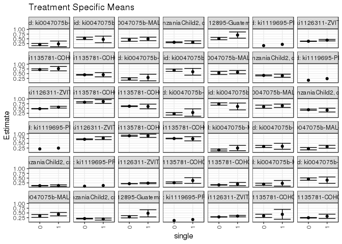

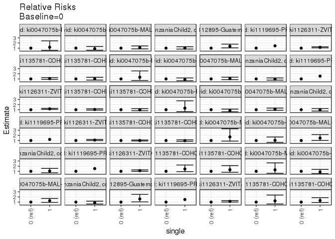

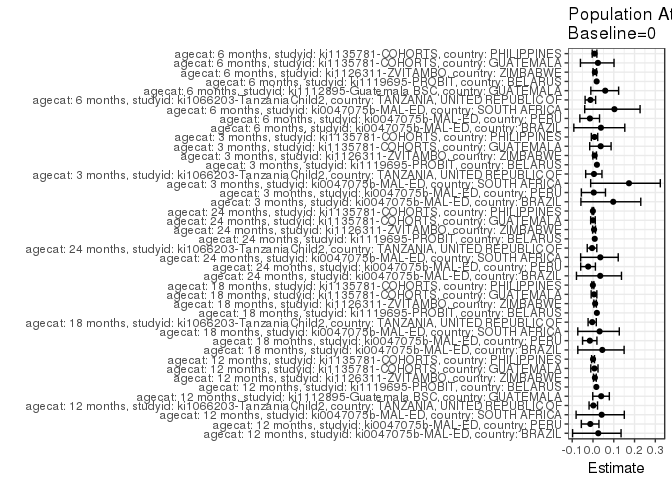

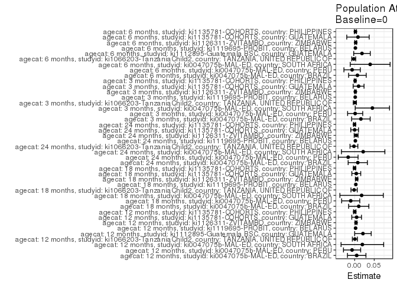

## Results Table

### Parameter: TSM

| agecat | studyid | country | intervention_level | baseline_level | estimate | ci_lower | ci_upper |
| --- | --- | --- | --- | --- | --- | --- | --- |
| 3 months | ki0047075b-MAL-ED | BRAZIL | 0 | NA | 0.1472081 | 0.0976247 | 0.1967915 |
| 3 months | ki0047075b-MAL-ED | BRAZIL | 1 | NA | 0.2500000 | 0.1082473 | 0.3917527 |
| 3 months | ki0047075b-MAL-ED | PERU | 0 | NA | 0.3320896 | 0.2756108 | 0.3885683 |
| 3 months | ki0047075b-MAL-ED | PERU | 1 | NA | 0.3428571 | 0.1853434 | 0.5003709 |
| 3 months | ki0047075b-MAL-ED | SOUTH AFRICA | 0 | NA | 0.2159091 | 0.1550251 | 0.2767931 |
| 3 months | ki0047075b-MAL-ED | SOUTH AFRICA | 1 | NA | 0.3188406 | 0.2409630 | 0.3967181 |
| 3 months | ki1066203-TanzaniaChild2 | TANZANIA, UNITED REPUBLIC OF | 0 | NA | 0.1019553 | 0.0891563 | 0.1147543 |
| 3 months | ki1066203-TanzaniaChild2 | TANZANIA, UNITED REPUBLIC OF | 1 | NA | 0.1071429 | 0.0666304 | 0.1476553 |
| 3 months | ki1119695-PROBIT | BELARUS | 0 | NA | 0.0726878 | NA | NA |
| 3 months | ki1119695-PROBIT | BELARUS | 1 | NA | 0.1111111 | NA | NA |
| 3 months | ki1126311-ZVITAMBO | ZIMBABWE | 0 | NA | 0.2080691 | 0.2011142 | 0.2150240 |
| 3 months | ki1126311-ZVITAMBO | ZIMBABWE | 1 | NA | 0.2347630 | 0.2068530 | 0.2626730 |
| 3 months | ki1135781-COHORTS | GUATEMALA | 0 | NA | 0.2601432 | 0.2180904 | 0.3021960 |
| 3 months | ki1135781-COHORTS | GUATEMALA | 1 | NA | 0.3750000 | 0.2248078 | 0.5251922 |
| 3 months | ki1135781-COHORTS | PHILIPPINES | 0 | NA | 0.1431486 | 0.1304890 | 0.1558082 |
| 3 months | ki1135781-COHORTS | PHILIPPINES | 1 | NA | 0.1866667 | 0.0984690 | 0.2748643 |
| 6 months | ki0047075b-MAL-ED | BRAZIL | 0 | NA | 0.1764706 | 0.1217058 | 0.2312354 |
| 6 months | ki0047075b-MAL-ED | BRAZIL | 1 | NA | 0.2258065 | 0.0782838 | 0.3733291 |
| 6 months | ki0047075b-MAL-ED | PERU | 0 | NA | 0.4497992 | 0.3878993 | 0.5116991 |
| 6 months | ki0047075b-MAL-ED | PERU | 1 | NA | 0.3939394 | 0.2269322 | 0.5609466 |
| 6 months | ki0047075b-MAL-ED | SOUTH AFRICA | 0 | NA | 0.3441558 | 0.2689817 | 0.4193300 |
| 6 months | ki0047075b-MAL-ED | SOUTH AFRICA | 1 | NA | 0.4358974 | 0.3458795 | 0.5259154 |
| 6 months | ki1066203-TanzaniaChild2 | TANZANIA, UNITED REPUBLIC OF | 0 | NA | 0.2032803 | 0.1856917 | 0.2208690 |
| 6 months | ki1066203-TanzaniaChild2 | TANZANIA, UNITED REPUBLIC OF | 1 | NA | 0.1764706 | 0.1241459 | 0.2287953 |
| 6 months | ki1112895-Guatemala BSC | GUATEMALA | 0 | NA | 0.2983193 | 0.2400834 | 0.3565553 |
| 6 months | ki1112895-Guatemala BSC | GUATEMALA | 1 | NA | 0.4814815 | 0.2926566 | 0.6703063 |
| 6 months | ki1119695-PROBIT | BELARUS | 0 | NA | 0.1024312 | NA | NA |
| 6 months | ki1119695-PROBIT | BELARUS | 1 | NA | 0.1535714 | NA | NA |
| 6 months | ki1126311-ZVITAMBO | ZIMBABWE | 0 | NA | 0.2920635 | 0.2823992 | 0.3017278 |
| 6 months | ki1126311-ZVITAMBO | ZIMBABWE | 1 | NA | 0.3339286 | 0.2948656 | 0.3729915 |

[output cut: 54 more lines]

### Parameter: E(Y)

| agecat | studyid | country | intervention_level | baseline_level | estimate | ci_lower | ci_upper |
| --- | --- | --- | --- | --- | --- | --- | --- |
| 3 months | ki0047075b-MAL-ED | BRAZIL | NA | NA | 0.1630901 | 0.1155503 | 0.2106299 |
| 3 months | ki0047075b-MAL-ED | PERU | NA | NA | 0.3333333 | 0.2801668 | 0.3864999 |
| 3 months | ki0047075b-MAL-ED | SOUTH AFRICA | NA | NA | 0.2611465 | 0.2124837 | 0.3098093 |
| 3 months | ki1066203-TanzaniaChild2 | TANZANIA, UNITED REPUBLIC OF | NA | NA | 0.1024452 | 0.0902396 | 0.1146508 |
| 3 months | ki1119695-PROBIT | BELARUS | NA | NA | 0.0740923 | NA | NA |
| 3 months | ki1126311-ZVITAMBO | ZIMBABWE | NA | NA | 0.2097617 | 0.2030108 | 0.2165126 |
| 3 months | ki1135781-COHORTS | GUATEMALA | NA | NA | 0.2701525 | 0.2294861 | 0.3108189 |
| 3 months | ki1135781-COHORTS | PHILIPPINES | NA | NA | 0.1442308 | 0.1316904 | 0.1567712 |
| 6 months | ki0047075b-MAL-ED | BRAZIL | NA | NA | 0.1834862 | 0.1319869 | 0.2349856 |
| 6 months | ki0047075b-MAL-ED | PERU | NA | NA | 0.4432624 | 0.3851792 | 0.5013456 |
| 6 months | ki0047075b-MAL-ED | SOUTH AFRICA | NA | NA | 0.3837638 | 0.3257580 | 0.4417697 |
| 6 months | ki1066203-TanzaniaChild2 | TANZANIA, UNITED REPUBLIC OF | NA | NA | 0.2008123 | 0.1841290 | 0.2174955 |
| 6 months | ki1112895-Guatemala BSC | GUATEMALA | NA | NA | 0.3169811 | 0.2608532 | 0.3731091 |
| 6 months | ki1119695-PROBIT | BELARUS | NA | NA | 0.1042654 | NA | NA |
| 6 months | ki1126311-ZVITAMBO | ZIMBABWE | NA | NA | 0.2946498 | 0.2852646 | 0.3040350 |
| 6 months | ki1135781-COHORTS | GUATEMALA | NA | NA | 0.3555556 | 0.2745076 | 0.4366035 |
| 6 months | ki1135781-COHORTS | PHILIPPINES | NA | NA | 0.2493685 | 0.2332567 | 0.2654802 |
| 12 months | ki0047075b-MAL-ED | BRAZIL | NA | NA | 0.2028986 | 0.1479811 | 0.2578160 |
| 12 months | ki0047075b-MAL-ED | PERU | NA | NA | 0.5185185 | 0.4588090 | 0.5782281 |
| 12 months | ki0047075b-MAL-ED | SOUTH AFRICA | NA | NA | 0.4710425 | 0.4101339 | 0.5319511 |
| 12 months | ki1066203-TanzaniaChild2 | TANZANIA, UNITED REPUBLIC OF | NA | NA | 0.3185260 | 0.2980043 | 0.3390477 |
| 12 months | ki1112895-Guatemala BSC | GUATEMALA | NA | NA | 0.5338346 | 0.4737728 | 0.5938964 |
| 12 months | ki1119695-PROBIT | BELARUS | NA | NA | 0.1456628 | NA | NA |
| 12 months | ki1126311-ZVITAMBO | ZIMBABWE | NA | NA | 0.3769959 | 0.3675653 | 0.3864264 |
| 12 months | ki1135781-COHORTS | GUATEMALA | NA | NA | 0.7196078 | 0.6805849 | 0.7586308 |
| 12 months | ki1135781-COHORTS | PHILIPPINES | NA | NA | 0.4397215 | 0.4210956 | 0.4583474 |
| 18 months | ki0047075b-MAL-ED | BRAZIL | NA | NA | 0.2319588 | 0.1724108 | 0.2915068 |
| 18 months | ki0047075b-MAL-ED | PERU | NA | NA | 0.6721311 | 0.6131080 | 0.7311543 |
| 18 months | ki0047075b-MAL-ED | SOUTH AFRICA | NA | NA | 0.5573123 | 0.4959861 | 0.6186384 |
| 18 months | ki1066203-TanzaniaChild2 | TANZANIA, UNITED REPUBLIC OF | NA | NA | 0.4056669 | 0.3803586 | 0.4309752 |
| 18 months | ki1119695-PROBIT | BELARUS | NA | NA | 0.1565217 | NA | NA |
| 18 months | ki1126311-ZVITAMBO | ZIMBABWE | NA | NA | 0.4913151 | 0.4798099 | 0.5028203 |
| 18 months | ki1135781-COHORTS | GUATEMALA | NA | NA | 0.8321513 | 0.7964937 | 0.8678089 |
| 18 months | ki1135781-COHORTS | PHILIPPINES | NA | NA | 0.6192308 | 0.6005626 | 0.6378990 |
| 24 months | ki0047075b-MAL-ED | BRAZIL | NA | NA | 0.2272727 | 0.1651836 | 0.2893619 |
| 24 months | ki0047075b-MAL-ED | PERU | NA | NA | 0.7201835 | 0.6604557 | 0.7799113 |
| 24 months | ki0047075b-MAL-ED | SOUTH AFRICA | NA | NA | 0.6157025 | 0.5542897 | 0.6771153 |
| 24 months | ki1066203-TanzaniaChild2 | TANZANIA, UNITED REPUBLIC OF | NA | NA | 0.4342380 | 0.4028349 | 0.4656411 |
| 24 months | ki1119695-PROBIT | BELARUS | NA | NA | 0.2061657 | NA | NA |
| 24 months | ki1126311-ZVITAMBO | ZIMBABWE | NA | NA | 0.7162667 | 0.6958561 | 0.7366773 |
| 24 months | ki1135781-COHORTS | GUATEMALA | NA | NA | 0.8963964 | 0.8680183 | 0.9247745 |
| 24 months | ki1135781-COHORTS | PHILIPPINES | NA | NA | 0.7530620 | 0.7362586 | 0.7698654 |

### Parameter: RR

| agecat | studyid | country | intervention_level | baseline_level | estimate | ci_lower | ci_upper |
| --- | --- | --- | --- | --- | --- | --- | --- |
| 3 months | ki0047075b-MAL-ED | BRAZIL | 0 | 0 | 1.0000000 | 1.0000000 | 1.000000 |
| 3 months | ki0047075b-MAL-ED | BRAZIL | 1 | 0 | 1.6982759 | 0.8781869 | 3.284199 |
| 3 months | ki0047075b-MAL-ED | PERU | 0 | 0 | 1.0000000 | 1.0000000 | 1.000000 |
| 3 months | ki0047075b-MAL-ED | PERU | 1 | 0 | 1.0324238 | 0.6325634 | 1.685046 |
| 3 months | ki0047075b-MAL-ED | SOUTH AFRICA | 0 | 0 | 1.0000000 | 1.0000000 | 1.000000 |
| 3 months | ki0047075b-MAL-ED | SOUTH AFRICA | 1 | 0 | 1.4767353 | 1.0169108 | 2.144482 |
| 3 months | ki1066203-TanzaniaChild2 | TANZANIA, UNITED REPUBLIC OF | 0 | 0 | 1.0000000 | 1.0000000 | 1.000000 |
| 3 months | ki1066203-TanzaniaChild2 | TANZANIA, UNITED REPUBLIC OF | 1 | 0 | 1.0508806 | 0.7055470 | 1.565240 |
| 3 months | ki1119695-PROBIT | BELARUS | 0 | 0 | 1.0000000 | NA | NA |
| 3 months | ki1119695-PROBIT | BELARUS | 1 | 0 | 1.5286077 | NA | NA |
| 3 months | ki1126311-ZVITAMBO | ZIMBABWE | 0 | 0 | 1.0000000 | 1.0000000 | 1.000000 |
| 3 months | ki1126311-ZVITAMBO | ZIMBABWE | 1 | 0 | 1.1282935 | 0.9972147 | 1.276602 |
| 3 months | ki1135781-COHORTS | GUATEMALA | 0 | 0 | 1.0000000 | 1.0000000 | 1.000000 |
| 3 months | ki1135781-COHORTS | GUATEMALA | 1 | 0 | 1.4415138 | 0.9359333 | 2.220203 |
| 3 months | ki1135781-COHORTS | PHILIPPINES | 0 | 0 | 1.0000000 | 1.0000000 | 1.000000 |
| 3 months | ki1135781-COHORTS | PHILIPPINES | 1 | 0 | 1.3040063 | 0.8063387 | 2.108832 |
| 6 months | ki0047075b-MAL-ED | BRAZIL | 0 | 0 | 1.0000000 | 1.0000000 | 1.000000 |
| 6 months | ki0047075b-MAL-ED | BRAZIL | 1 | 0 | 1.2795699 | 0.6207971 | 2.637414 |
| 6 months | ki0047075b-MAL-ED | PERU | 0 | 0 | 1.0000000 | 1.0000000 | 1.000000 |
| 6 months | ki0047075b-MAL-ED | PERU | 1 | 0 | 0.8758117 | 0.5608385 | 1.367677 |
| 6 months | ki0047075b-MAL-ED | SOUTH AFRICA | 0 | 0 | 1.0000000 | 1.0000000 | 1.000000 |
| 6 months | ki0047075b-MAL-ED | SOUTH AFRICA | 1 | 0 | 1.2665699 | 0.9377374 | 1.710713 |
| 6 months | ki1066203-TanzaniaChild2 | TANZANIA, UNITED REPUBLIC OF | 0 | 0 | 1.0000000 | 1.0000000 | 1.000000 |
| 6 months | ki1066203-TanzaniaChild2 | TANZANIA, UNITED REPUBLIC OF | 1 | 0 | 0.8681145 | 0.6374338 | 1.182276 |
| 6 months | ki1112895-Guatemala BSC | GUATEMALA | 0 | 0 | 1.0000000 | 1.0000000 | 1.000000 |
| 6 months | ki1112895-Guatemala BSC | GUATEMALA | 1 | 0 | 1.6139802 | 1.0414655 | 2.501218 |
| 6 months | ki1119695-PROBIT | BELARUS | 0 | 0 | 1.0000000 | NA | NA |
| 6 months | ki1119695-PROBIT | BELARUS | 1 | 0 | 1.4992635 | NA | NA |
| 6 months | ki1126311-ZVITAMBO | ZIMBABWE | 0 | 0 | 1.0000000 | 1.0000000 | 1.000000 |
| 6 months | ki1126311-ZVITAMBO | ZIMBABWE | 1 | 0 | 1.1433424 | 1.0124630 | 1.291140 |

[output cut: 54 more lines]

### Parameter: PAR

| agecat | studyid | country | intervention_level | baseline_level | estimate | ci_lower | ci_upper |
| --- | --- | --- | --- | --- | --- | --- | --- |
| 3 months | ki0047075b-MAL-ED | BRAZIL | 0 | NA | 0.0158820 | -0.0078083 | 0.0395723 |
| 3 months | ki0047075b-MAL-ED | PERU | 0 | NA | 0.0012438 | -0.0180890 | 0.0205766 |
| 3 months | ki0047075b-MAL-ED | SOUTH AFRICA | 0 | NA | 0.0452374 | 0.0014257 | 0.0890491 |
| 3 months | ki1066203-TanzaniaChild2 | TANZANIA, UNITED REPUBLIC OF | 0 | NA | 0.0004899 | -0.0035228 | 0.0045025 |
| 3 months | ki1119695-PROBIT | BELARUS | 0 | NA | 0.0014045 | NA | NA |
| 3 months | ki1126311-ZVITAMBO | ZIMBABWE | 0 | NA | 0.0016926 | -0.0001344 | 0.0035196 |
| 3 months | ki1135781-COHORTS | GUATEMALA | 0 | NA | 0.0100093 | -0.0039027 | 0.0239214 |
| 3 months | ki1135781-COHORTS | PHILIPPINES | 0 | NA | 0.0010822 | -0.0011467 | 0.0033111 |
| 6 months | ki0047075b-MAL-ED | BRAZIL | 0 | NA | 0.0070157 | -0.0154783 | 0.0295096 |
| 6 months | ki0047075b-MAL-ED | PERU | 0 | NA | -0.0065368 | -0.0274849 | 0.0144113 |
| 6 months | ki0047075b-MAL-ED | SOUTH AFRICA | 0 | NA | 0.0396080 | -0.0113147 | 0.0905307 |
| 6 months | ki1066203-TanzaniaChild2 | TANZANIA, UNITED REPUBLIC OF | 0 | NA | -0.0024680 | -0.0075600 | 0.0026239 |
| 6 months | ki1112895-Guatemala BSC | GUATEMALA | 0 | NA | 0.0186618 | -0.0025515 | 0.0398751 |
| 6 months | ki1119695-PROBIT | BELARUS | 0 | NA | 0.0018342 | NA | NA |
| 6 months | ki1126311-ZVITAMBO | ZIMBABWE | 0 | NA | 0.0025863 | 0.0000917 | 0.0050808 |
| 6 months | ki1135781-COHORTS | GUATEMALA | 0 | NA | 0.0084481 | -0.0202521 | 0.0371483 |
| 6 months | ki1135781-COHORTS | PHILIPPINES | 0 | NA | 0.0018657 | -0.0009271 | 0.0046584 |
| 12 months | ki0047075b-MAL-ED | BRAZIL | 0 | NA | 0.0051584 | -0.0184860 | 0.0288028 |
| 12 months | ki0047075b-MAL-ED | PERU | 0 | NA | -0.0066916 | -0.0286683 | 0.0152851 |
| 12 months | ki0047075b-MAL-ED | SOUTH AFRICA | 0 | NA | 0.0196536 | -0.0348194 | 0.0741266 |
| 12 months | ki1066203-TanzaniaChild2 | TANZANIA, UNITED REPUBLIC OF | 0 | NA | 0.0005460 | -0.0059487 | 0.0070406 |
| 12 months | ki1112895-Guatemala BSC | GUATEMALA | 0 | NA | 0.0211227 | 0.0000009 | 0.0422445 |
| 12 months | ki1119695-PROBIT | BELARUS | 0 | NA | 0.0023578 | NA | NA |
| 12 months | ki1126311-ZVITAMBO | ZIMBABWE | 0 | NA | 0.0034664 | 0.0009857 | 0.0059472 |
| 12 months | ki1135781-COHORTS | GUATEMALA | 0 | NA | 0.0050109 | -0.0074230 | 0.0174448 |
| 12 months | ki1135781-COHORTS | PHILIPPINES | 0 | NA | 0.0001280 | -0.0029416 | 0.0031975 |
| 18 months | ki0047075b-MAL-ED | BRAZIL | 0 | NA | 0.0104019 | -0.0154467 | 0.0362505 |
| 18 months | ki0047075b-MAL-ED | PERU | 0 | NA | -0.0101118 | -0.0332868 | 0.0130631 |
| 18 months | ki0047075b-MAL-ED | SOUTH AFRICA | 0 | NA | 0.0177439 | -0.0377517 | 0.0732395 |
| 18 months | ki1066203-TanzaniaChild2 | TANZANIA, UNITED REPUBLIC OF | 0 | NA | -0.0014868 | -0.0094972 | 0.0065236 |
| 18 months | ki1119695-PROBIT | BELARUS | 0 | NA | 0.0029315 | NA | NA |
| 18 months | ki1126311-ZVITAMBO | ZIMBABWE | 0 | NA | 0.0050550 | 0.0020903 | 0.0080198 |
| 18 months | ki1135781-COHORTS | GUATEMALA | 0 | NA | 0.0041090 | -0.0072757 | 0.0154936 |
| 18 months | ki1135781-COHORTS | PHILIPPINES | 0 | NA | -0.0003045 | -0.0032161 | 0.0026072 |
| 24 months | ki0047075b-MAL-ED | BRAZIL | 0 | NA | 0.0079179 | -0.0166880 | 0.0325237 |
| 24 months | ki0047075b-MAL-ED | PERU | 0 | NA | -0.0166586 | -0.0419695 | 0.0086522 |
| 24 months | ki0047075b-MAL-ED | SOUTH AFRICA | 0 | NA | 0.0217175 | -0.0337609 | 0.0771959 |
| 24 months | ki1066203-TanzaniaChild2 | TANZANIA, UNITED REPUBLIC OF | 0 | NA | -0.0018955 | -0.0119012 | 0.0081102 |
| 24 months | ki1119695-PROBIT | BELARUS | 0 | NA | 0.0017458 | NA | NA |
| 24 months | ki1126311-ZVITAMBO | ZIMBABWE | 0 | NA | 0.0036884 | -0.0013070 | 0.0086838 |
| 24 months | ki1135781-COHORTS | GUATEMALA | 0 | NA | -0.0000683 | -0.0099691 | 0.0098326 |
| 24 months | ki1135781-COHORTS | PHILIPPINES | 0 | NA | -0.0003793 | -0.0030733 | 0.0023147 |

### Parameter: PAF

| agecat | studyid | country | intervention_level | baseline_level | estimate | ci_lower | ci_upper |
| --- | --- | --- | --- | --- | --- | --- | --- |
| 3 months | ki0047075b-MAL-ED | BRAZIL | 0 | NA | 0.0973818 | -0.0580956 | 0.2300132 |
| 3 months | ki0047075b-MAL-ED | PERU | 0 | NA | 0.0037313 | -0.0559886 | 0.0600739 |
| 3 months | ki0047075b-MAL-ED | SOUTH AFRICA | 0 | NA | 0.1732262 | -0.0111887 | 0.3240085 |
| 3 months | ki1066203-TanzaniaChild2 | TANZANIA, UNITED REPUBLIC OF | 0 | NA | 0.0047819 | -0.0351644 | 0.0431868 |
| 3 months | ki1119695-PROBIT | BELARUS | 0 | NA | 0.0189564 | NA | NA |
| 3 months | ki1126311-ZVITAMBO | ZIMBABWE | 0 | NA | 0.0080692 | -0.0006773 | 0.0167392 |
| 3 months | ki1135781-COHORTS | GUATEMALA | 0 | NA | 0.0370506 | -0.0157567 | 0.0871126 |
| 3 months | ki1135781-COHORTS | PHILIPPINES | 0 | NA | 0.0075031 | -0.0080621 | 0.0228280 |
| 6 months | ki0047075b-MAL-ED | BRAZIL | 0 | NA | 0.0382353 | -0.0922097 | 0.1531010 |
| 6 months | ki0047075b-MAL-ED | PERU | 0 | NA | -0.0147470 | -0.0631491 | 0.0314515 |
| 6 months | ki0047075b-MAL-ED | SOUTH AFRICA | 0 | NA | 0.1032093 | -0.0399273 | 0.2266444 |
| 6 months | ki1066203-TanzaniaChild2 | TANZANIA, UNITED REPUBLIC OF | 0 | NA | -0.0122903 | -0.0379572 | 0.0127419 |
| 6 months | ki1112895-Guatemala BSC | GUATEMALA | 0 | NA | 0.0588735 | -0.0103760 | 0.1233768 |
| 6 months | ki1119695-PROBIT | BELARUS | 0 | NA | 0.0175912 | NA | NA |
| 6 months | ki1126311-ZVITAMBO | ZIMBABWE | 0 | NA | 0.0087774 | 0.0002758 | 0.0172067 |
| 6 months | ki1135781-COHORTS | GUATEMALA | 0 | NA | 0.0237603 | -0.0604053 | 0.1012456 |
| 6 months | ki1135781-COHORTS | PHILIPPINES | 0 | NA | 0.0074816 | -0.0037775 | 0.0186145 |
| 12 months | ki0047075b-MAL-ED | BRAZIL | 0 | NA | 0.0254237 | -0.0982473 | 0.1351684 |
| 12 months | ki0047075b-MAL-ED | PERU | 0 | NA | -0.0129052 | -0.0562201 | 0.0286335 |
| 12 months | ki0047075b-MAL-ED | SOUTH AFRICA | 0 | NA | 0.0417236 | -0.0812874 | 0.1507404 |
| 12 months | ki1066203-TanzaniaChild2 | TANZANIA, UNITED REPUBLIC OF | 0 | NA | 0.0017141 | -0.0188852 | 0.0218969 |
| 12 months | ki1112895-Guatemala BSC | GUATEMALA | 0 | NA | 0.0395679 | -0.0011365 | 0.0786174 |
| 12 months | ki1119695-PROBIT | BELARUS | 0 | NA | 0.0161868 | NA | NA |
| 12 months | ki1126311-ZVITAMBO | ZIMBABWE | 0 | NA | 0.0091949 | 0.0025920 | 0.0157541 |
| 12 months | ki1135781-COHORTS | GUATEMALA | 0 | NA | 0.0069634 | -0.0104838 | 0.0241093 |
| 12 months | ki1135781-COHORTS | PHILIPPINES | 0 | NA | 0.0002911 | -0.0067141 | 0.0072474 |
| 18 months | ki0047075b-MAL-ED | BRAZIL | 0 | NA | 0.0448436 | -0.0730704 | 0.1498007 |
| 18 months | ki0047075b-MAL-ED | PERU | 0 | NA | -0.0150444 | -0.0501993 | 0.0189336 |
| 18 months | ki0047075b-MAL-ED | SOUTH AFRICA | 0 | NA | 0.0318384 | -0.0731381 | 0.1265458 |
| 18 months | ki1066203-TanzaniaChild2 | TANZANIA, UNITED REPUBLIC OF | 0 | NA | -0.0036652 | -0.0236074 | 0.0158886 |
| 18 months | ki1119695-PROBIT | BELARUS | 0 | NA | 0.0187290 | NA | NA |
| 18 months | ki1126311-ZVITAMBO | ZIMBABWE | 0 | NA | 0.0102888 | 0.0042316 | 0.0163092 |
| 18 months | ki1135781-COHORTS | GUATEMALA | 0 | NA | 0.0049378 | -0.0088524 | 0.0185395 |
| 18 months | ki1135781-COHORTS | PHILIPPINES | 0 | NA | -0.0004917 | -0.0052049 | 0.0041994 |
| 24 months | ki0047075b-MAL-ED | BRAZIL | 0 | NA | 0.0348387 | -0.0795305 | 0.1370912 |
| 24 months | ki0047075b-MAL-ED | PERU | 0 | NA | -0.0231311 | -0.0591171 | 0.0116323 |
| 24 months | ki0047075b-MAL-ED | SOUTH AFRICA | 0 | NA | 0.0352727 | -0.0593328 | 0.1214294 |
| 24 months | ki1066203-TanzaniaChild2 | TANZANIA, UNITED REPUBLIC OF | 0 | NA | -0.0043651 | -0.0276745 | 0.0184157 |
| 24 months | ki1119695-PROBIT | BELARUS | 0 | NA | 0.0084680 | NA | NA |
| 24 months | ki1126311-ZVITAMBO | ZIMBABWE | 0 | NA | 0.0051495 | -0.0018554 | 0.0121054 |
| 24 months | ki1135781-COHORTS | GUATEMALA | 0 | NA | -0.0000761 | -0.0111825 | 0.0109083 |
| 24 months | ki1135781-COHORTS | PHILIPPINES | 0 | NA | -0.0005036 | -0.0040875 | 0.0030675 |